# W3cubDocs

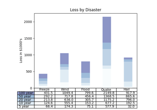

[Table Demo](https://matplotlib.org/3.5.1/gallery/misc/table_demo.html#sphx-glr-gallery-misc-table-demo-py)

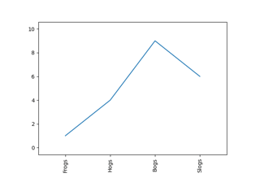

[Rotating custom tick labels](https://matplotlib.org/3.5.1/gallery/ticks/ticklabels_rotation.html#sphx-glr-gallery-ticks-ticklabels-rotation-py)

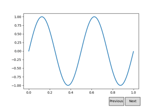

[Buttons](https://matplotlib.org/3.5.1/gallery/widgets/buttons.html#sphx-glr-gallery-widgets-buttons-py)

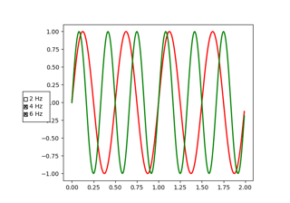

[Check Buttons](https://matplotlib.org/3.5.1/gallery/widgets/check_buttons.html#sphx-glr-gallery-widgets-check-buttons-py)

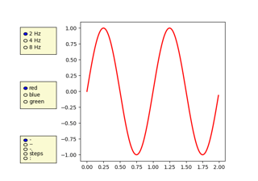

[Radio Buttons](https://matplotlib.org/3.5.1/gallery/widgets/radio_buttons.html#sphx-glr-gallery-widgets-radio-buttons-py)

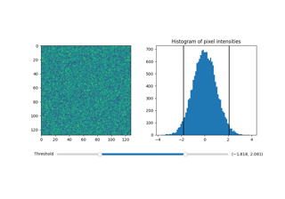

[Thresholding an Image with RangeSlider](https://matplotlib.org/3.5.1/gallery/widgets/range_slider.html#sphx-glr-gallery-widgets-range-slider-py)

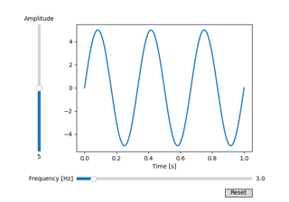

[Slider](https://matplotlib.org/3.5.1/gallery/widgets/slider_demo.html#sphx-glr-gallery-widgets-slider-demo-py)

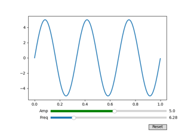

[Snapping Sliders to Discrete Values](https://matplotlib.org/3.5.1/gallery/widgets/slider_snap_demo.html#sphx-glr-gallery-widgets-slider-snap-demo-py)

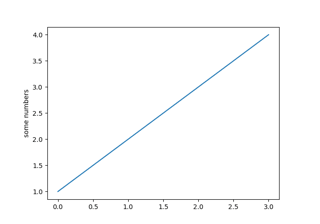

[Pyplot tutorial](https://matplotlib.org/3.5.1/tutorials/introductory/pyplot.html#sphx-glr-tutorials-introductory-pyplot-py)